# Business Viability of Commercial Fisheries

2026-11-16

# Profitability

Profitability provides an indication of the financial performance of different fleet segments over time. Operating profit is considered alongside net profit because the two measures capture different aspects of financial performance. Operating profit reflects the performance of fishing operation before depreciation, interest and financing costs, while net profit also includes these things.

The analysis considers both the latest available profitability estimates and the frequency with which average vessels within each fleet segment have recorded losses over the available time series.

**Table 1: Profitability indicators by fleet segment**

| Fleet segment | Operating profit year | Operating profit (£’000) | Years with operating loss (%) | Net profit year | Net profit (£’000) | Years with net loss (%) |
| --- | --- | --- | --- | --- | --- | --- |
| Overall | 2025 | 148.7 | 0.0 | 2024 | 109.4 | 0.0 |
| Low activity, over 10m | 2025 | -3.3 | 100.0 | 2024 | -13.4 | 100.0 |
| Low activity, under 10m | 2025 | 0.0 | 22.2 | 2024 | -1.0 | 64.7 |
| Demersal trawl, under 10m | 2025 | 12.9 | 0.0 | 2024 | 5.8 | 0.0 |
| Pots and traps, under 10m | 2025 | 20.3 | 0.0 | 2024 | 13.1 | 0.0 |
| Hooks, under 10m | 2025 | 27.1 | 0.0 | 2024 | 25.9 | 5.9 |
| WOS nephrops, under 250kW | 2025 | 31.9 | 0.0 | 2024 | 14.1 | 5.9 |
| North Sea nephrops, under 300kW | 2025 | 37.1 | 0.0 | 2024 | 21.1 | 11.8 |
| NSWOS demersal, under 24m under 300kW | 2021 | 41.3 | 0.0 | 2021 | 20.1 | 0.0 |
| Pots and traps, 10-12m | 2025 | 43.4 | 0.0 | 2024 | 22.9 | 0.0 |
| North Sea nephrops, over 250kW | 2025 | 53.4 | 5.6 | 2024 | -11.3 | 41.2 |
| Dredge, under 15m | 2025 | 55.4 | 0.0 | 2024 | 41.4 | 17.6 |
| Pots and traps, over 12m | 2025 | 66.5 | 0.0 | 2024 | 41.8 | 5.9 |
| NSWOS demersal, under 24m over 300kW | 2025 | 104.9 | 0.0 | 2024 | -26.4 | 35.3 |
| North Sea nephrops, under 300kW | 2025 | 106.1 | 0.0 | 2024 | -61.8 | 52.9 |
| Longliners | 2025 | 160.2 | 5.6 | 2024 | 156.5 | 23.5 |
| NSWOS demersal seiners | 2025 | 204.0 | 0.0 | 2024 | -54.3 | 17.6 |
| Dredge, over 15m | 2025 | 217.0 | 0.0 | 2024 | 105.2 | 5.9 |
| NSWOS demersal pair trawl seine | 2025 | 387.9 | 0.0 | 2024 | 111.9 | 5.9 |
| NSWOS demersal, over 24m | 2025 | 438.6 | 0.0 | 2024 | -45.8 | 17.6 |

Table 1 highlights substantial differences in both the level and consistency of profitability across fleet segments. While most segments recorded positive operating profit in the latest available year, the frequency of historical losses varies considerably between segments. The differences are more pronounced for net profit, with several segments experiencing net losses in a meaningful proportion of observed years despite recording positive operating profits.

This distinction is important because the latest available profit provides only a snapshot of financial performance. The proportion of years in which losses were recorded provides additional evidence on the persistence and stability of profitability over time. The results therefore suggest that assessments of business viability should consider both the current financial position and historical variability rather than relying on a single year’s profitability.

## Operating profit

**Figure 1: Operating profit per vessel by fleet segment over time**

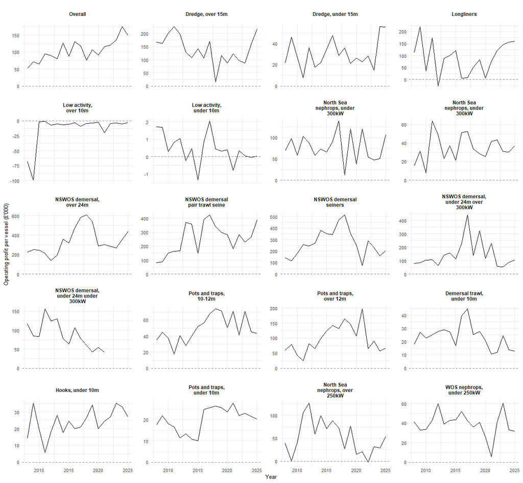

Figure 1 shows substantial variation in operating profit per vessel across fleet segments and over time. Some larger demersal segments generate operating profits considerably above the fleet average, while smaller-vessel segments generally generate much lower absolute profits per vessel. This partly reflects differences in the scale and characteristics of fishing businesses and means that absolute profit levels should be interpreted cautiously when comparing segments.

Operating profitability also varies considerably over time for some fleet segments. Several segments experience pronounced increases and decreases in operating profit rather than a consistent trend, while others show comparatively stable performance. The Scotland-level series remains positive throughout the period and generally increases over the longer term, but this aggregate trend masks substantial differences between individual segments.

## Net profit

**Figure 2: Net profit per vessel by fleet segment over time**

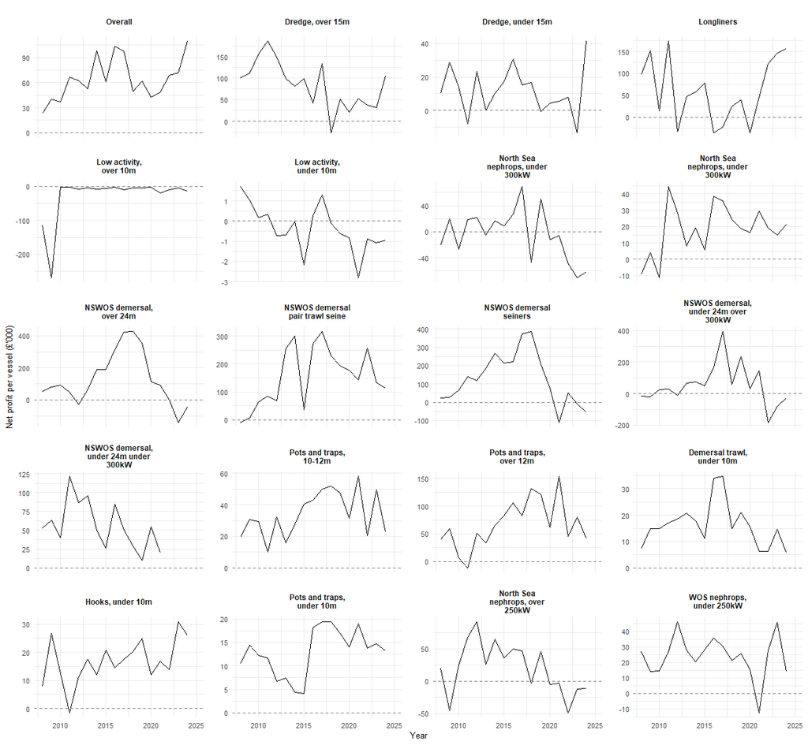

**Data note:** Valid net profit estimates are not available for 2025 because depreciation, interest and other finance costs are not available for that year. Net profit analysis therefore ends in 2024 for most fleet segments. The latest available year also differs for some individual segments where data are unavailable.

Figure 2 shows that the financial position of some fleet segments becomes weaker when depreciation, interest and other finance costs are taken into account. Periods of negative net profit occur more frequently than periods of negative operating profit, indicating that positive returns from fishing operations do not necessarily translate into positive overall financial returns once these additional costs are included.

There is also considerable variation in net profit over time. Some segments move between positive and negative net profitability across the period, including segments that generate relatively high operating profits. This suggests that both the level and stability of profitability are relevant when considering financial viability. Persistent or recurring losses may indicate greater financial pressure, while consistently positive net profitability provides stronger evidence of sustained financial performance.

## Operating profit margin

Absolute operating profit differs substantially across fleet segments, in part reflecting differences in the scale and characteristics of fishing businesses. Operating profit margin provides an additional measure that accounts for these differences in scale by expressing operating profit per vessel as a proportion of average total income per vessel.

**Figure 3: Operating profit margin per vessel by fleet segment over time**

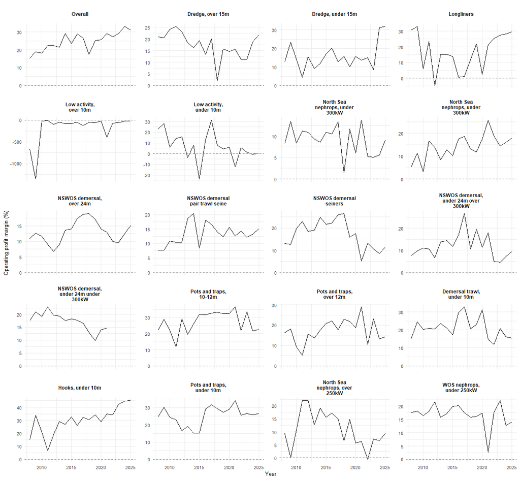

Operating margins vary considerably across fleet segments and over time. The overall fleet operating margin increased over the period and was approximately 31% in 2025. Several smaller-vessel segments have relatively high operating margins despite generating substantially lower operating profit per vessel in real terms. For example, the under-10 metre hooks segment had a n operating margin of approximately 45% in 2025.

Conversely, some larger demersal and nephrops segments generated substantially higher absolute operating profits but had lower operating margins. This shows that higher operating profit per vessel does not necessarily imply stronger profitability relative to the scale of the business.

## Findings

Profitability varies substantially across fleet segments, both in the level of profit generated and its stability over time. The overall Scotland-level results mask considerable differences between individual fleet segments.

The profitability measures provide different perspectives on financial performance. Absolute operating profit shows the size of the financial surplus generated per vessel, while operating margin provides an indication of this surplus relative to income. Several smaller-vessel segments have relatively strong operating margins despite substantially lower absolute profits, demonstrating the importance of considering both measures.

Some fleet segments with positive profits in the latest available year experienced net losses relatively frequently over the historical period. This indicates that a single year’s profitability does not fully represent the stability of financial performance within each segment.

The low-activity fleet exhibits particularly weak or volatile profitability, although these categories are not the primary focus of this assessment.

High absolute profitability should also not automatically be interpreted as evidence of greater resilience. Some higher-profit fleet segments display substantial year-to-year variation and have experienced periods of negative net profitability.

These findings provide evidence on historical financial performance rather than a direct measure of resilience to spatial displacement. Profitability therefore needs to be considered alongside income and costs, fishing activity, productivity and fleet characteristics before drawing wider conclusions about the capacity of different fleet segments to absorb additional spatial pressures.

# Income and costs

Income and costs provide additional context for the profitability results by showing how the financial position of different fleet segments has developed over time. All financial values are expressed in 2025 prices using the GDP deflator, meaning changes over time represent changes in real rather than nominal values.

## Income and total costs

**Figure 4: Total Income and total costs per vessel by fleet segment over time**

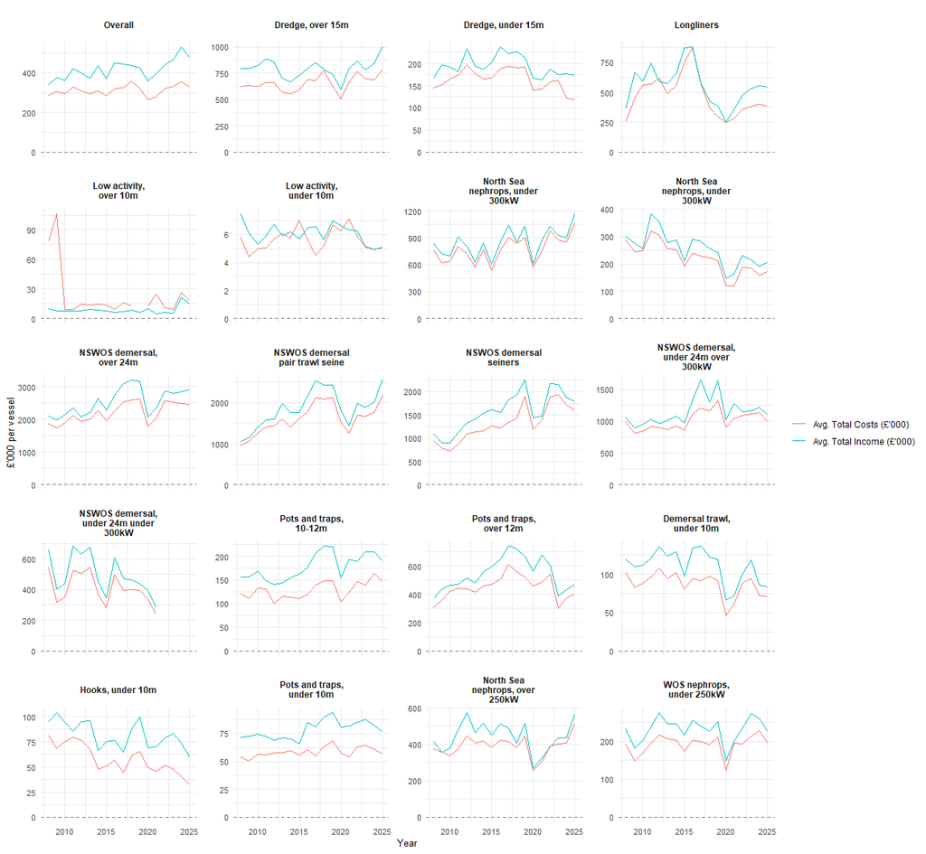

Figure 4 shows substantial differeneces in the scale of income and costs across fleet segments. This reflects differences in vessel size, activity and business characteristics and means that absolute financial values should be interpreted cautiously when comparing segments.

Across much of the fleet, average total income generally remains above average total costs, consistent with the predominantly positive operating profits identified in the profitability analysis. However, the gap between income and costs varies considerably across fleet segments and over time. Some segments also experience relatively large year-to-year movements in real income compared with costs, contributing to the variation in profitability observed over the period.

The overall fleet position therefore masks substantial differences in the financial experience of individual fleet segments.

## Cost composition

The composition of total costs also varies across the fleet. Table 2 presents each major cost component as a percentage of average total costs, allowing cost structures to be compared across fleet segments of substantially different sizes.

**Table 2: Composition of average total costs by fleet segment, latest available year**

| Fleet segment | Latest year | Fuel (%) | Crew (%) | Other fishing (%) | Vessel (%) |
| --- | --- | --- | --- | --- | --- |
| Overall | 2025 | 12.7 | 42.2 | 19.8 | 25.3 |
| Dredge, over 15m | 2025 | 18.2 | 42.7 | 8.7 | 30.4 |
| Dredge, under 15m | 2025 | 17.4 | 34.5 | 10.8 | 37.3 |
| Longliners | 2025 | 13.3 | 51.3 | 9.2 | 26.2 |
| Low activity, over 10m | 2025 | 8.0 | 7.9 | 37.6 | 46.5 |
| Low activity, under 10m | 2025 | 5.9 | 24.7 | 16.2 | 53.2 |
| North Sea nephrops, under 300kW | 2025 | 19.7 | 34.1 | 22.1 | 24.0 |
| North Sea nephrops, under 300kW | 2025 | 13.1 | 35.9 | 7.5 | 43.5 |
| NSWOS demersal, over 24m | 2025 | 19.1 | 31.1 | 29.2 | 20.5 |
| NSWOS demersal pair trawl seine | 2025 | 8.7 | 40.0 | 30.2 | 21.1 |
| NSWOS demersal seiners | 2025 | 12.8 | 31.0 | 26.2 | 30.1 |
| NSWOS demersal, under 24m over 300kW | 2025 | 15.4 | 24.3 | 30.4 | 30.0 |
| NSWOS demersal, under 24m under 300kW | 2021 | 18.4 | 35.4 | 20.2 | 26.0 |
| Pots and traps, 10-12m | 2025 | 8.0 | 30.8 | 25.3 | 36.0 |
| Pots and traps, over 12m | 2025 | 9.3 | 44.0 | 18.7 | 28.1 |
| Demersal trawl, under 10m | 2025 | 16.6 | 42.3 | 12.4 | 28.7 |
| Hooks, under 10m | 2025 | 3.8 | 31.8 | 20.8 | 43.7 |
| Pots and traps, under 10m | 2025 | 4.9 | 39.6 | 23.4 | 32.0 |
| North Sea nephrops, over 250kW | 2025 | 16.4 | 40.4 | 12.6 | 30.6 |
| WOS nephrops, under 250kW | 2025 | 15.0 | 37.7 | 16.9 | 30.4 |

**Figure 5: Composition of average total costs by fleet segment over time**

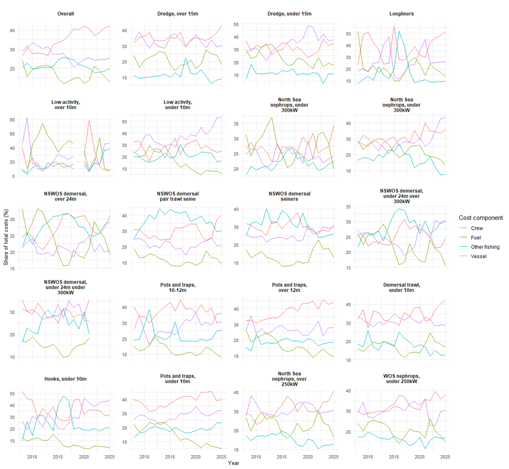

Crew costs account for substantial proportion of total costs across much of the fleet. For the overall fleet, crew costs accounted for approximately 42% of average total costs in 2025, compared with approximately 25% for vessel costs, 20% for other fishing costs and 13% for fuel.

Figure 5 shows that cost structures are not fixed over time. The relative importance of fuel, crew, other fishing and vessel costs has changed within a number of fleet segments. This means that different segments may be exposed to different forms of cost pressure, and that exposure can itself change over time.

Differences in cost composition may also be relevant when considering potential displacement pressures. For example, fleet segments for which fuel represents a larger proportion of costs could be more exposed to changes that increase steaming requirements. However, the cost data describe existing cost structures and do not in themselves demonstrate the effect of future spatial displacement.

# Drivers of profitability

Profitability depends not only on the absolute level of income and costs but also on the returns generated relative to fishing activity and vessel capacity. Measures expressed per kW day at sea provide an additional perspective on the efficiency with which different fleet segments convert vessel capacity and fishing activity into income and operating surplus.

**Figure 6: Fishing income, total costs and operating profit per kW-day by fleet segment over time**

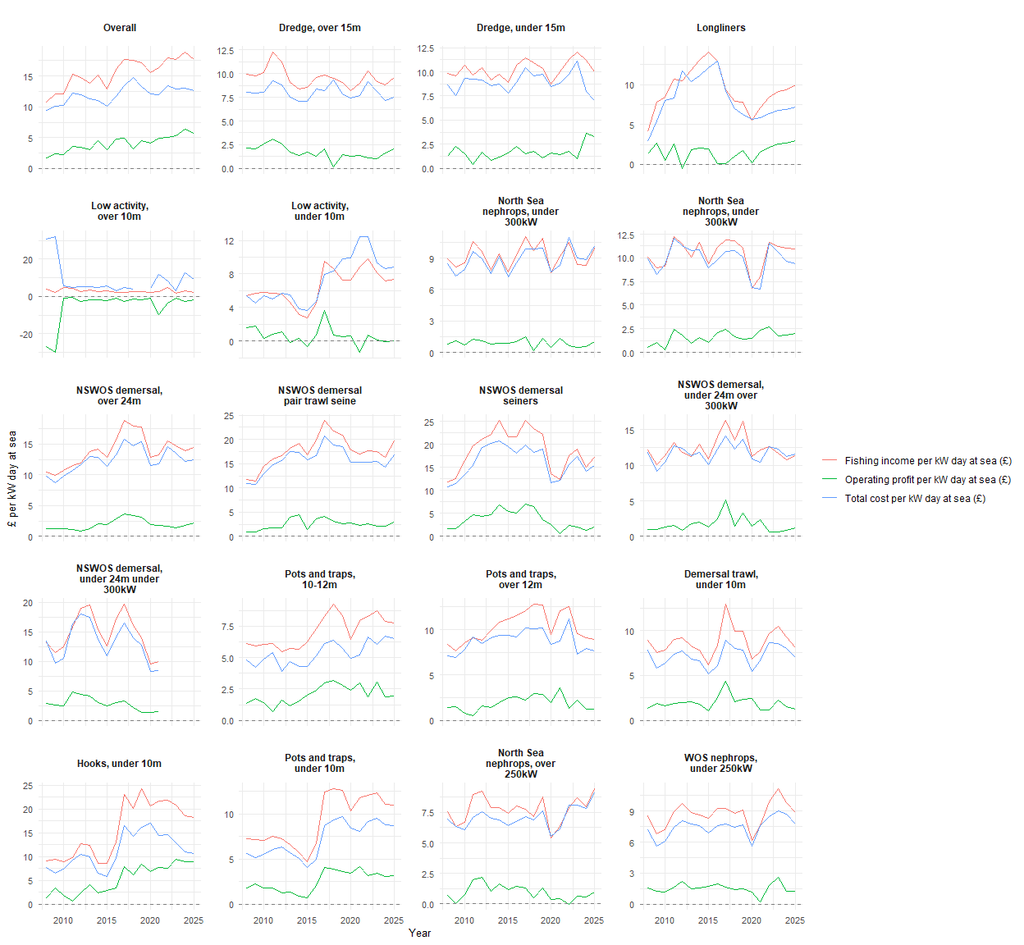

Fishing income per kW day at sea generally exceeds total costs per kW day across the commercially active fleet, although the size and stability of the resulting operating surplus varies substantially between fleet segments. For the overall fleet in 2025, fishing income was approximately £17.70 per kW day compared with total costs of £12.60, resulting in operating profit of £5.70 per kW day.

The results also demonstrate that high absolute profit per vessel does not necessarily correspond to the highest returns relative to vessel capacity and activity. Some smaller-vessel segments generate comparatively strong operating profits per kW day despite substantially lower absolute operating profits per vessel. Conversely, some larger fleet segments generate substantial absolute profits but more modest operating returns when measured relative to capacity and fishing activity.

The underlying drivers of these returns also differ between fleet segments. Analysis of landings per day at sea shows considerable variation in physical catch productivity, while real prices per tonne vary substantially across fisheries. Differences in income generation therefore reflect a combination of the volume of catch generated from fishing activity and the value obtained for that catch.

These measures should not be interpreted as direct ranking of business viability across fleet segments. A kW day is not necessarily economically equivalent across different vessel sizes, gears and fisheries. The measures are therefore most informative when considered alongside absolute profitability and when assessing changes within fleet segments over time.

# Fishing activity

Fishing activity provides additional context for changes in financial performance and helps distinguish changes in the overall scale of the fleet from changes in the activity and productivity of individual vessels.

## Fishing activity over time

**Figure 7: Total days at sea**

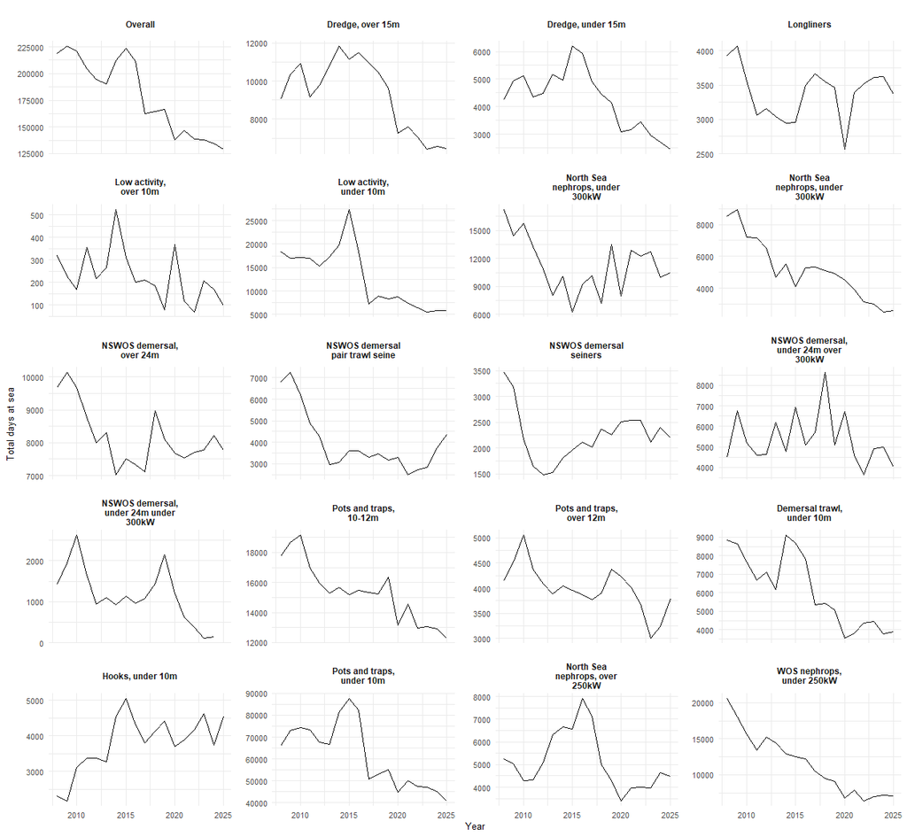

Total days at sea have declined substantially across the Scottish fleet over the period. At the overall level, total days at sea fell from approximately 220,000 days towards the beginning of the period to around 130,000 days in the latest year. Declining total days at sea are also evident across a number of individual fleet segments, although the scale and timing of these changes varies considerably.

This reduction in aggregate fishing activity needs to be considered alongside changes in fleet structure. The total number of vessels has also declined over the period, from approximately 1,850 vessels towards the beginning of the series to around 1,520 in 2025. Consequently, part of the reduction in total days at sea reflects a smaller fleet rather than solely a reduction in the activity of individual vessels.

Average days at sea per vessel have also fallen overall, although the pattern varies substantially across fleet segments. Some segments show marked reductions in average fishing days, while others have remained relatively stable or increased activity in recent years.

Taken together, the results indicate that the fleet has become smaller and has undertaken fewer aggregate days at sea, while maintaining total landings at levels that have not declined proportionately. This is consistent with greater landings relative to fishing time amongst the remaining fleet. However, this should not be interpreted solely as an improvement in technical efficiency, as changes in fleet composition, vessel characteristics, target fisheries and the vessels remaining active may also contribute to the observed pattern.

## Fleet size

**Figure 8: Number of vessels**

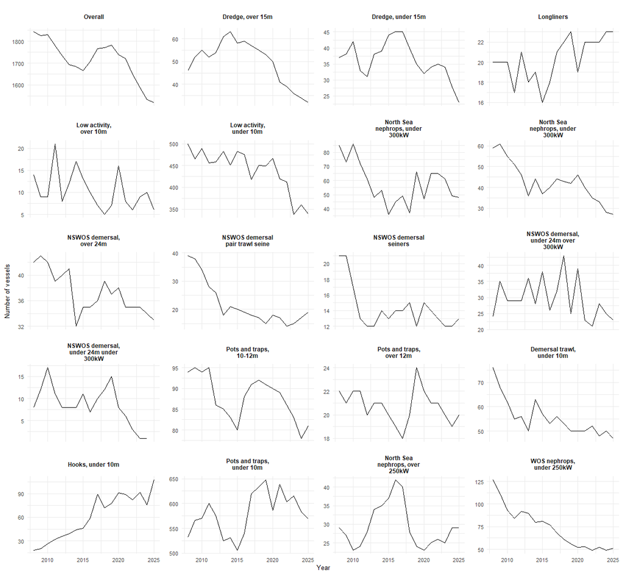

Figure 8 shows a long-term decline in the number of vessels in the overall Scottish fleet. Vessel numbers fell from approximately 1,850 towards the beginning of the period to around 1,520 in 2025. This decline is evident across a number of fleet segments, although the scale and direction of change varies between them. Some segments have experienced substantial contractions in vessel numbers, while others have remained relatively stable or increased.

The reduction in vessel numbers explains part of the decline in aggregate fishing activity shown in Figure 7. Fewer vessel numbers are contributing to total days at sea, meaning that the reduction in aggregate activity should not be interpreted solely as individual vessels spending less time fishing. Average days at sea per vessel have also declined overall, indicating that both a smaller fleet and changes in the activity of remaining vessels have contributed to the reduction in total days at sea.

Employment has also fallen substantially over the period, broadly supporting the evidence of a reduction in the overall scale of the fleet. However, trends in vessel numbers and employment are not uniform across fleet segments, highlighting the importance of considering changes in fleet composition alongside the overall trend.

Despite the reduction in vessel numbers and aggregate days at sea, total landings have not declined proportionately. This coincides with an increase in average landings per day at sea at the overall fleet level. Taken together, the evidence suggests that the fleet has become smaller and undertaken fewer aggregate fishing days while maintaining a comparatively high level of aggregate landings.

This should not be interpreted as evidence that fleet contraction has itself caused greater productivity. Changes in fleet composition, vessel characteristics, target fisheries and the characteristics of vessels remaining active may all contribute to the observed relationship. Nevertheless, the results demonstrate that changes in the scale of the fleet are an important part of the context when assessing trends in fishing activity and business viability.

# Fleet Structure

Changes in fleet structure provide important context for the trends in activity, productivity and financial performance identified above. Table 3 below summarises changes in selected characteristics of the overall fleet between 2008 and 2025.

**Table 3: Change in overall fleet structure, 2008-2025**

| Indicator | 2008 | 2025 | Change |
| --- | --- | --- | --- |
| Average vessel capacity (VCU) | 169.2 | 169.3 | 0.1 |
| Average vessel age (years) | 22.0 | 27.6 | 5.6 |
| Average length (m) | 12.3 | 11.5 | -0.8 |
| Employment (FTE) | 4772.0 | 3023.9 | -36.6% |
| Number of vessels | 1843.0 | 1520.0 | -17.5% |

Changes in fleet structure provide important context for the trends in activity, productivity and financial performance identified above. Table 3 summarises changes in selected characteristics of the overall fleet between 2008 and 2025.

Changes in average vessel characteristics are less pronounced. Average vessel length declined from 12.3 metres to 11.5 metres, while average vessel capacity, measured using Vessel Capacity Units, remained broadly unchanged at around 169. The contraction in vessel numbers has therefore not been accompanied by a comparable reduction in the average capacity measure of vessels remaining in the fleet.

The fleet has also aged over the period. Average vessel age increased from approximately 22 years in 2008 to 28 years in 2025. This may be relevant to longer-term business viability, including investment and vessel replacement considerations, although vessel age alone does not indicate the condition or economic viability of individual vessels.

The overall figures also mask considerable changes in the composition of the fleet. Vessel numbers and employment have declined substantially within several individual fleet segments, while a smaller number of segments have expanded. Changes in aggregate measures of fishing activity and productivity should therefore be interpreted partly in the context of this changing fleet composition rather than solely in the behaviour or performance of otherwise unchanged businesses.